# HW3

Dennis Tseng

2018/3/17

#### This is the 7.5.1.1 exercise from chapter 7 **Exploratory Data Analysis** in *R for Data Science*.

#### The question is “Use what you have learned to improve the visualisation of the departure times of cancelled vs. non-cancelled flights.”

```r
library(tidyverse)
library(nycflights13)
options(Encoding="UTF-8")
data(flights)
str(flights)

# arr_time = NA means that the flight was cancelled
# add cancelled column to identify
flights_cancellation <- flights %>%
  mutate(cancelled = is.na(arr_time))
```

#### Now I am going to plot the result. There are several options I can choose to plot.

#### Before plotting, we have to know the type of variables, which are “cancelled” and “dep_time” in this case.

```r
head(flights_cancellation$cancelled)
```

```
## [1] FALSE FALSE FALSE FALSE FALSE FALSE
```

```r
head(flights_cancellation$dep_time)
```

```
## [1] 517 533 542 544 554 554
```

#### Now we know that “cancelled” is a categorical variable and “dep_time” is a continuous variable.

#### Les’s plot!

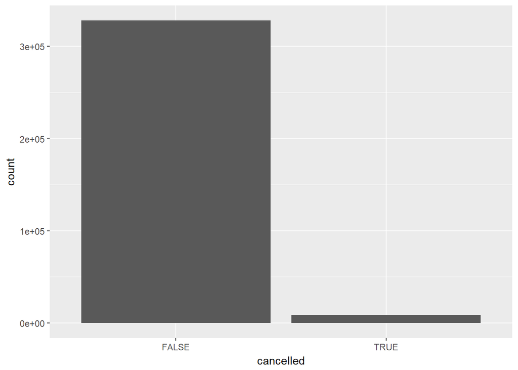

```r
# plot01
# draw the plot00
flights_cancellation %>%
  ggplot(aes(x = cancelled)) +
  geom_bar()
```

#### It is quite clear that there is counts gap within flights.

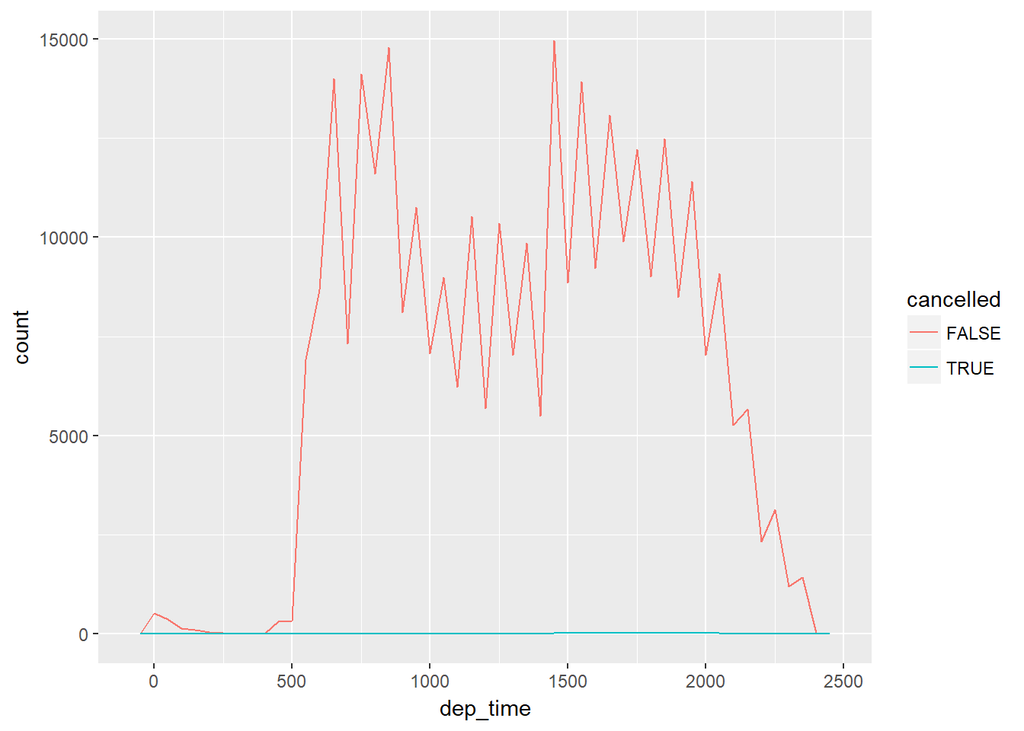

```r
# plot01
flights_cancellation %>%
  ggplot(aes(x = dep_time)) +
  geom_freqpoly(aes(col = cancelled), binwidth = 50)
```

#### As you can see, since the counts of cancelled flights are largely less than not-cancelled flights, we can’t observe the trend of cancelled flights. Thus, we should change from `geom_freqpoly()` to `geom_density()`.

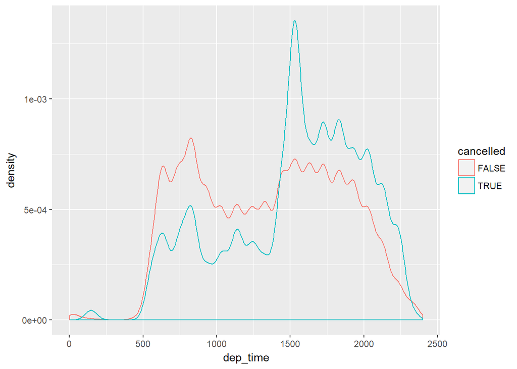

```r
# plot02
flights_cancellation %>%
  ggplot(aes(x = dep_time)) +
  geom_density(aes(col = cancelled), bw = 40)
```

#### As you can see, there are some pattern between cancelled and not-cancelled flights.

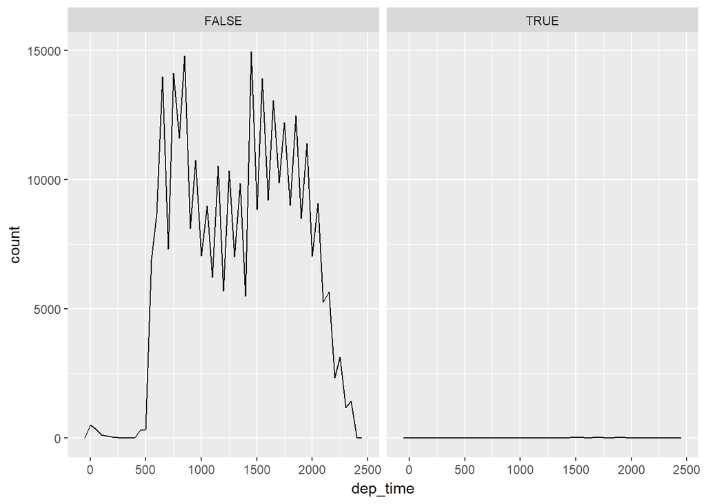

```r
# dplot03
flights_cancellation %>%
  ggplot(aes(x = dep_time)) +
  geom_freqpoly(binwidth = 50) +
  facet_grid( . ~ cancelled)
```

#### Let’s add `facet_grid()` to the plot, but we need to remember to adjust the geom function.

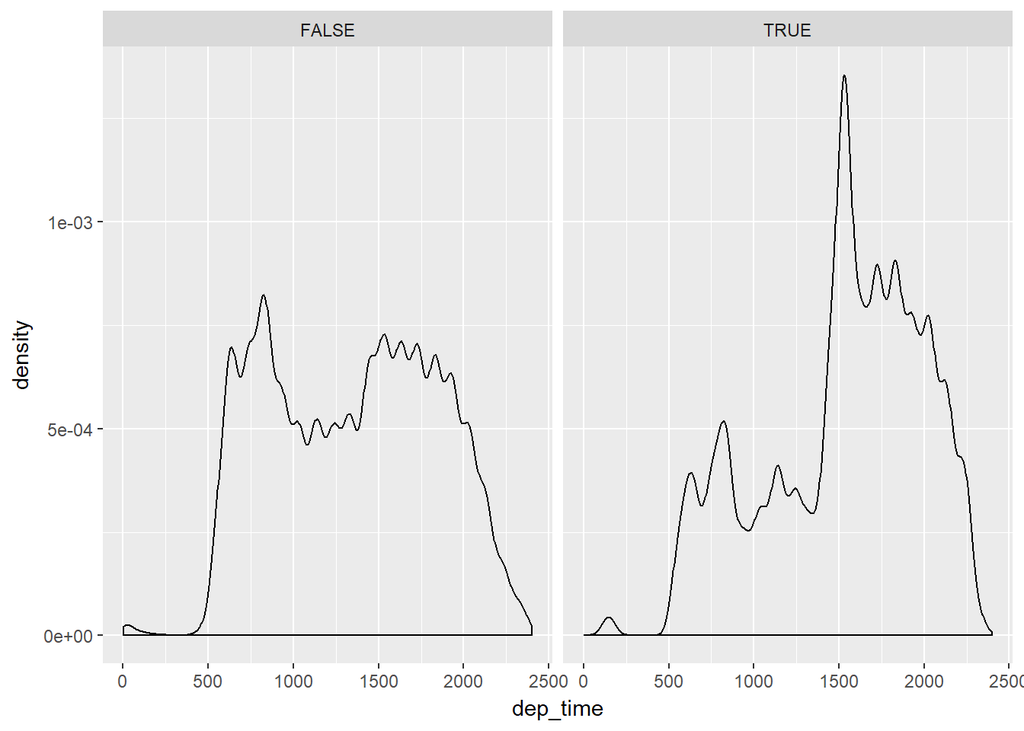

```r
# plot04
flights_cancellation %>%
  ggplot(aes(x = dep_time)) +
  geom_density(bw = 40) +
  facet_grid( . ~ cancelled)
```

#### As you can see, `facet_grid()` looks great.

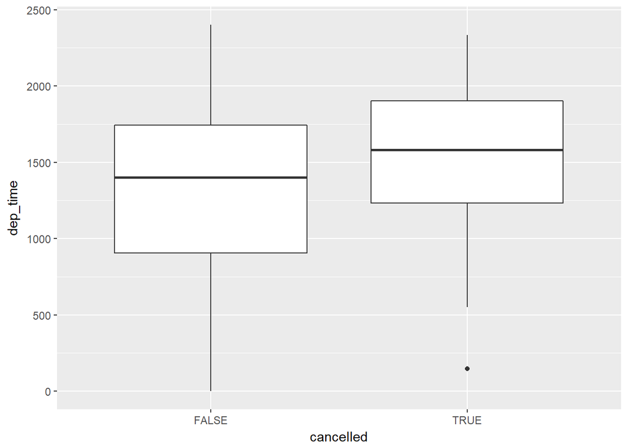

```r
# plot05
flights_cancellation %>%
  ggplot(aes(x = cancelled, y = dep_time)) +
  geom_boxplot()
```

#### As you can see, `geom_boxplot()` is also great.

#### To sum up, we use `geom_freqpoly`, `geom_density` and `geom_boxplot()` to plot two variables which are “cancelled” and “dep_time”. Since there are counts gap, we have to use density to replace counts. Boxplot is also useful to compare continuous variable broken down by a categorical variable.